# Spotify Data Project

Author

Iris Buisman

# A Musical Data Analysis: Phoebe Bridgers

## Introducing Phoebe Bridgers

### A Brief Biography

Phoebe Bridgers is an American singer originally from Pasadena in California whose music has been described as indie rock, indie pop and indie folk. She started playing the guitar in middle school, and spent time as a teenager busking at farmer’s markets. Whilst she was originally accepted to Berklee to study voice, she dropped out very fast to focus fully on her professional music career. Her first album, ‘Stranger in the Alps’ was released in 2017, and her second album, ‘Punisher’ was released 3 years later in 2020. She has also collaborated with artists such as SZA, Taylor Swift, Muna and Lorde. Her music is quite melancholy, as she writes about her complicated relationship with her parents, past breakups, as well as mental health. She has moreover released a string of Christmas covers and original songs.

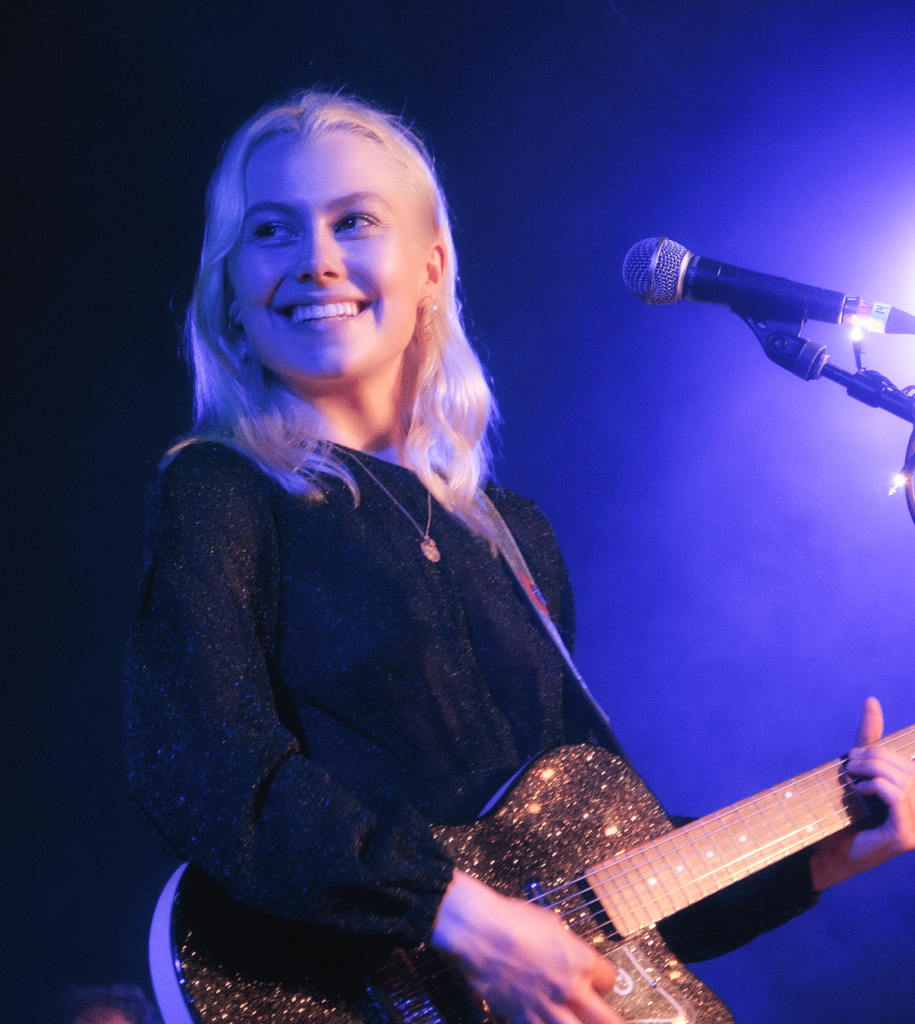

Phoebe Bridgers

### Boygenius

In 2018, Phoebe Bridgers formed a super group with fellow artists Lucy Dacus and Julien Baker - Boygenius. The group came into existence after the three became friends, sharing frustrations over the fact that the music industry would frequently pit them against each other because they were all female musicians working in the same genre. They have released an EP, called ‘Boygenius’, in 2018, their first album entitled ‘The Record’ in 2023, and a second EP entitled ‘The Rest’ in 2023. ‘The Record’ topped charts in the UK, the Netherlands and Ireland, and was an enormous success, both commercially and critically. The group is currently on hiatus - fans hope they will return to make more music soon.

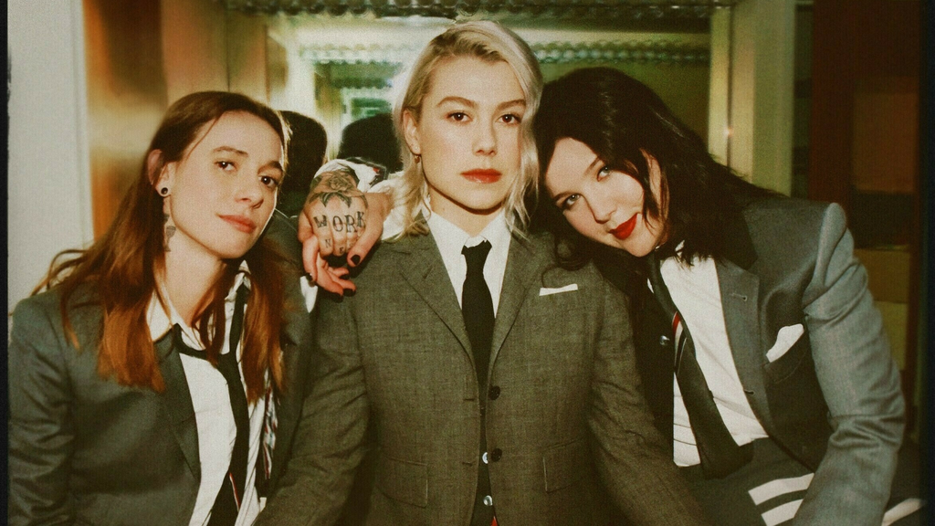

Boygenius (Julien Baker, Phoebe Bridgers, Lucy Dacus)

### Albums

Phoebe Bridgers has released the following albums solo:

[figure not shown]

‘Stranger in the Alps’ - 2017

[figure not shown]

‘Punisher’ - 2020

Two EPs with Boygenius:

[figure not shown]

‘Boygenius’ - 2018

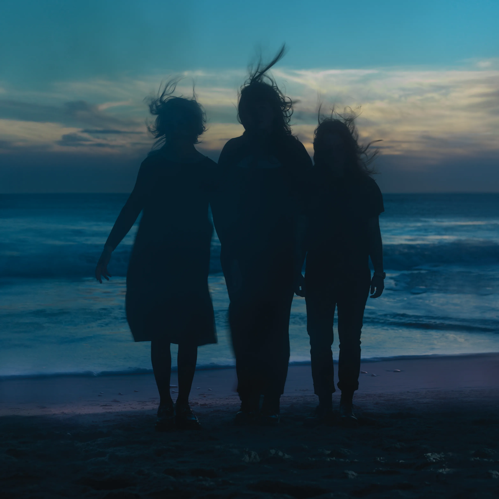

‘The Rest’ - 2023

And one album with Boygenius:

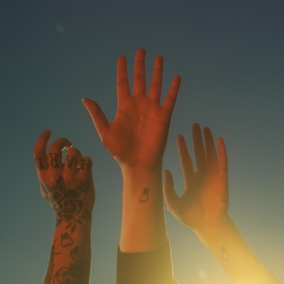

‘The Record’ - 2023

### Major Awards

Phoebe Bridgers has won, and been nominated for, a great variety of awards, including:

- Won an AIM Award for Independent Breakthrough of the Year in 2018
- Was nominated for a Grammy in 2021 for ‘Punisher’ (Best Alternative Music Album), “Kyoto” (Best Rock Song/Rock Performance) and Best New Artist
- Won the Grammy for Best Alternative Music Album for ‘The Record’ , the Grammy for Best Rock song for ‘Not Strong Enough’ and for Best Rock Performance for ‘Not Strong Enough’ with Boygenius in 2024, as well as the Grammy for Best Pop Duo/Group Performance for ‘Ghost in the Machine’ with SZA in 2024
- Won the Brit Award for Best International Group with Boygenius in 2024

## My Favorites

### Favorite Album

I don’t really think I have a favorite Phoebe Bridgers album - she doesn’t have a very large discography, and all of her songs are really good. Whilst I was working on this project, I was listening to ‘Punisher’, which I really like because I think it is a very well-constructed album, with a storytelling arch to the way the songs are placed in the album, opening with an instrumental and ending with the very cathartic ‘I Know the End’. The lyrics to the songs on the album are very emotionally open and honest, which I think is another strength of the album, and of Bridgers’ musical style in general.

### Favorite Song

Because I, again, am really bad at making these kinds of decisions, I’ve picked the song that is currently my favorite song off each album.

#### From the album ‘A Stranger in the Alps’ : ‘Scott Street’

I love the song ‘Scott Street’ because I find it a very dual song - on one hand, it is reflective on time passing, and looking back on past relationships, but it also has a nostalgic, warm ending. The ending, which features sounds like a steam train, which appears to be either returning or leaving a station, and overlapping instrumentals, feels both very nostalgic and comforting, which is a balance struck throughout the song. Bridgers’ lyrics emphasize how odd it is to reconnect with somebody who you once shared everything with, and realizing that you now don’t share anything anymore.

[Scott Street Live](https://www.youtube.com/watch?v=W-Khe7DInxo)

[video not shown]

#### From the album ‘Punisher’ : ‘Chinese Satellite’

Whilst I usually listen more to other songs on this album, I’ve recently really enjoyed listening to ‘Chinese Satellite’. The use of changing tempos gives the song a really cool dynamic, especially because of the song’s use of percussion. The song itself can, like many of Phoebe Bridgers’ music, be interpreted in different ways, but she herself has said that it is about her struggle with agnosticism. She has written that the song is about her inner desire to become more religious, yet knowing that she cannot really become religious as she simply does not believe in God.

[Chinese Satellite Music Video](https://www.youtube.com/watch?v=i63yumCNdJs)

[video not shown]

#### From the album ‘The Record’ - ‘Not Strong Enough’

From the Boygenius album, ‘Not Strong Enough’ has been the song I have listened to the most - for good reason. The song is catchy, very well written and sung, and has multiple changes in tempo. The bridge especially is incredibly cathartic, expressing the struggle to uphold relationships when you are struggling yourself.

[Not Strong Enough](https://www.youtube.com/watch?v=rTcF-tZwlXI)

[video not shown]

### Some of my Favorite Lyrics:

> Either way, we’re not alone  
> I’ll find a new place to be from

> **‘I Know the End’**

> I’ve been running around in circles  
> Pretending to be myself

> **‘Chinese Satellite’**

> I wish I was on a spaceship, Just me and my dog and an impossible view

> **‘Me and My Dog’**

## Data Analysis

### Data Preparation

#### Data Source

The data used in this analysis is from Spotify’s ‘Spotify for Developers’ website, from the year 2022. As this was a very large data set, with many artists included, I filtered the data set to include only songs for which Phoebe Bridgers was an artist.

#### Importing Data

```r
# I first loaded the packages I needed for the analysis
library(ggplot2)
library(dplyr)

#I then imported the data into df
df <- read.csv("/Users/irisbuisman/Desktop/assignment2/dataset.csv", sep = ";", header = TRUE)
```

#### The Data Frame

```r
#I then sliced the data frame
df |> dplyr::slice_sample(n=15) |> knitr::kable(digits = 2)
```

| artists | album_name | track_name | popularity | duration_ms | explicit | danceability | energy | key | loudness | mode | speechiness | acousticness | instrumentalness | liveness | valence | tempo | time_signature | track_genre |
| --- | --- | --- | --- | --- | --- | --- | --- | --- | --- | --- | --- | --- | --- | --- | --- | --- | --- | --- |
| Lord Huron;Phoebe Bridgers | 13 Reasons Why (Season 2) | The Night We Met (feat. Phoebe Bridgers) | 68 | 208173 | FALSE | 424 | 437 | 2 | -8.59 | 1 | 0.04 | 962 | 336.00 | 664.00 | 131 | 174.13 | 3 | indie |
| The Killers;Phoebe Bridgers | The Greatest Rock Tunes 2022 | Runaway Horses - Abridged | 0 | 204466 | FALSE | 499 | 223 | 9 | -15.25 | 1 | 0.03 | 912 | 0.00 | 0.10 | 304 | 129.29 | 5 | alt-rock |
| Lord Huron;Phoebe Bridgers | 13 Reasons Why (Season 2) | The Night We Met (feat. Phoebe Bridgers) | 68 | 208173 | FALSE | 424 | 437 | 2 | -8.59 | 1 | 0.04 | 962 | 336.00 | 664.00 | 131 | 174.13 | 3 | folk |
| Julien Baker;Phoebe Bridgers;Lucy Dacus | boygenius | Me & My Dog | 61 | 206465 | FALSE | 487 | 509 | 0 | -9.05 | 1 | 0.02 | 580 | 0.01 | 115.00 | 200 | 94.02 | 4 | ambient |
| Julien Baker;Phoebe Bridgers;Lucy Dacus | boygenius | Souvenir | 60 | 212467 | FALSE | 605 | 299 | 6 | -11.19 | 0 | 0.03 | 751 | 474.00 | 0.09 | 181 | 109.01 | 4 | ambient |
| Julien Baker;Phoebe;Lucy Dacus Bridgers | boygenius | Salt In The Wound | 55 | 251469 | FALSE | 417 | 361 | 2 | -7.59 | 1 | 0.03 | 204 | 0.00 | 0.10 | 285 | 62.53 | 3 | ambient |
| Julien Baker;Phoebe Bridgers;Lucy Dacus | boygenius | Bite The Hand | 57 | 192070 | FALSE | 543 | 507 | 10 | -8.12 | 1 | 0.03 | 374 | 0.03 | 0.11 | 193 | 100.13 | 4 | ambient |
| The Killers;Phoebe Bridgers | The Greatest Rock Tunes 2022 | Runaway Horses - Abridged | 0 | 204466 | FALSE | 499 | 223 | 9 | -15.25 | 1 | 0.03 | 912 | 0.00 | 0.10 | 304 | 129.29 | 5 | alternative |
| Lord Huron;Phoebe Bridgers | The Night We Met | The Night We Met | 61 | 209081 | FALSE | 424 | 362 | 9 | -11.11 | 1 | 0.04 | 974 | 0.18 | 632.00 | 123 | 174.15 | 3 | folk |
| The Killers;Phoebe Bridgers | The Greatest Rock Tunes 2022 | Runaway Horses - Abridged | 0 | 204466 | FALSE | 499 | 223 | 9 | -15.25 | 1 | 0.03 | 912 | 0.00 | 0.10 | 304 | 129.29 | 5 | alternative |
| Phoebe Bridgers | Punisher | Moon Song | 72 | 277676 | FALSE | 339 | 243 | 1 | -12.51 | 1 | 56.00 | 869 | 0.00 | 107.00 | 183 | 154.91 | 3 | indie-pop |
| Phoebe Bridgers | Stranger in the Alps | Motion Sickness | 77 | 229760 | FALSE | 651 | 546 | 1 | -9.02 | 1 | 0.04 | 774 | 0.04 | 0.08 | 623 | 107.02 | 4 | indie-pop |
| Julien Baker;Phoebe Bridgers;Lucy Dacus | boygenius | Ketchum, ID | 54 | 215689 | FALSE | 393 | 104 | 0 | -12.15 | 1 | 0.03 | 908 | 0.00 | 389.00 | 214 | 117.85 | 3 | ambient |
| Phoebe Bridgers | Stranger in the Alps | Motion Sickness | 77 | 229760 | FALSE | 651 | 546 | 1 | -9.02 | 1 | 0.04 | 774 | 0.04 | 0.08 | 623 | 107.02 | 4 | indie-pop |

From the data frame, it is clear that this data set did not include a great many of Phoebe Bridgers’ songs, with only one song from each of her solo albums included. The only ‘album’ which is nearly included in full is Boygenius’ first EP, from which five out of six songs are in the data set. It is acknowledged that this may represent a challenge for conducting data analysis, as this data set is unlikely to be representative of her music as a whole. However, it may still be possible to glean interesting insights from this data, hence I continued on my data exploration journey.

#### Cleaning up the data

```r
#Removal of track records that have the same name
df <- df |> distinct(track_name, .keep_all = TRUE)
#Filtering out any tracks with "feat"
df <- df |> filter(!grepl("feat.", track_name))
```

### Looking at valence

I thought it would be very interesting to analyze whether songs that have higher valence levels, and are hence happier, are more popular songs, or whether the opposite is true. Phoebe Bridgers’ music is not necessarily known for being very happy and upbeat, so I wondered whether there was a chance that actually the opposite was true - that the lower the valence score, the more popular the song.

I first created a boxplot for each album represented in the data, in order to compare the valence levels in each of the albums.

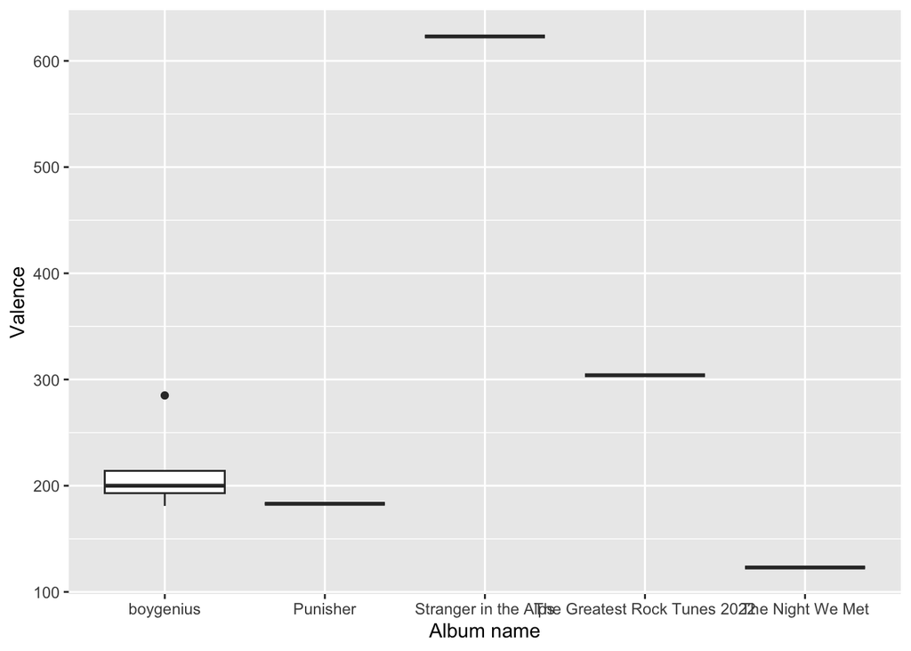

```r
# Changing album_name from a character to a factor
df$album_name <- as.factor(df$album_name)
# Plotting a boxplot
ggplot(df, aes(x=album_name, y=valence))+
  geom_boxplot()+
  labs(x="Album name", y="Valence")
```

As can be seen, across all albums, valence tends to be around the 200/300 level, with some being even closer to 100. Only ‘Stranger in the Alps’ has a song with a significantly higher valence, ‘Motion Sickness’, which has a valence level of 623. However, what is unfortunate about this data set is the very few songs per album that were included, hence one cannot really elucidate from these plots whether or not an album is happier than others. What can be seen from this visualization however, is that Bridgers’ music in general does not have high valence levels in general.

The only album which has multiple songs included in the data set is ‘boygenius’ which is the EP Bridgers worked on as part of the band Boygenius. Here, there is at least a proper boxplot build, although the majority of songs (up to the 75th percentile) still fall around a valence level of 200. It does have a singular outlier, which is the song ‘Salt in the Wound’, which, with a valence level of 285, is slightly happier than the other songs from the EP.

### Analyzing valence and popularity

I then wanted to find out whether these sadder songs were more popular than those with slightly higher valence levels, and I hence constructed a scatter plot of these two variables.

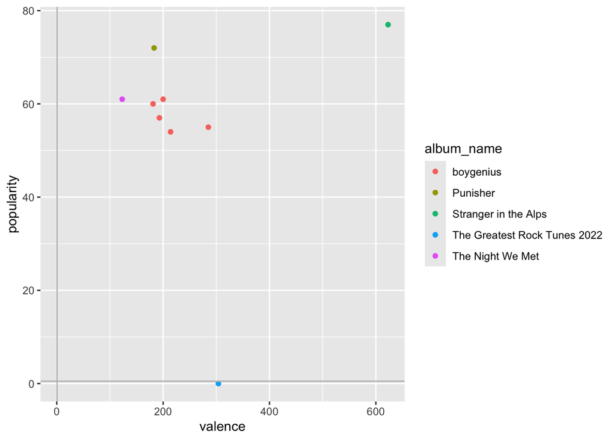

```r
#plotting a scatterplot with different colours per album
ggplot(df, aes(x = valence, y = popularity, color = album_name))+
  geom_point() + geom_hline(yintercept= 0.5, color="grey") + geom_vline(xintercept= 0.5, color= "grey")
```

It is challenging to analyse whether there is any relationship between popularity and valence, as all songs appear very clustered around low valence, and high popularity. This can again be due to a low number of songs being included in the data set. Perhaps a notable exception is the song ‘Runaway Horses’, which is a collaboration between Phoebe Bridgers and The Killers. The song’s very low popularity may be due to the fact that the version of the song included in the data set is not the version utilized on most playlists, instead coming of a seemingly obscure album. A small, slightly strangely organised data set, which draws from these obscure versions of songs can clearly be seen as not being a good foundation for a data analysis.

### Analyzing Boygenius’ EP

As mentioned before, the most represented album in the dataset is the EP Bridgers released as part of the band Boygenius in 2018, titled ‘boygenius’. As it is the most represented, I thought it would be interesting to do a deep dive into this album.

#### Importing Data

To make analyzing the album slightly simpler, I created a new data set, which I first imported into the software utilized.

```r
# I first loaded the packages I needed for the analysis
library(ggplot2)
library(dplyr)

#I then imported the data into df
df <- read.csv("/Users/irisbuisman/Desktop/assignment2/boygeniusdata.csv", sep = ";", header = TRUE)
```

#### The data frame

```r
#slicing the data frame
df |> dplyr::slice_sample(n=5) |> knitr::kable(digits = 2)
```

| artists | album_name | track_name | popularity | duration_ms | explicit | danceability | energy | key | loudness | mode | speechiness | acousticness | instrumentalness | liveness | valence | tempo | time_signature | track_genre |
| --- | --- | --- | --- | --- | --- | --- | --- | --- | --- | --- | --- | --- | --- | --- | --- | --- | --- | --- |
| Julien Baker;Phoebe Bridgers;Lucy Dacus | boygenius | Me & My Dog | 61 | 206465 | FALSE | 487 | 509 | 0 | -9.05 | 1 | 0.02 | 580 | 0.01 | 115.00 | 200 | 94.02 | 4 | ambient |
| Julien Baker;Phoebe;Lucy Dacus Bridgers | boygenius | Salt In The Wound | 55 | 251469 | FALSE | 417 | 361 | 2 | -7.59 | 1 | 0.03 | 204 | 0.00 | 0.10 | 285 | 62.53 | 3 | ambient |
| Julien Baker;Phoebe Bridgers;Lucy Dacus | boygenius | Souvenir | 60 | 212467 | FALSE | 605 | 299 | 6 | -11.19 | 0 | 0.03 | 751 | 474.00 | 0.09 | 181 | 109.01 | 4 | ambient |
| Julien Baker;Phoebe Bridgers;Lucy Dacus | boygenius | Ketchum, ID | 54 | 215689 | FALSE | 393 | 104 | 0 | -12.15 | 1 | 0.03 | 908 | 0.00 | 389.00 | 214 | 117.85 | 3 | ambient |
| Julien Baker;Phoebe Bridgers;Lucy Dacus | boygenius | Bite The Hand | 57 | 192070 | FALSE | 543 | 507 | 10 | -8.12 | 1 | 0.03 | 374 | 0.03 | 0.11 | 193 | 100.13 | 4 | ambient |

#### Analyzing Valence in Boygenius songs

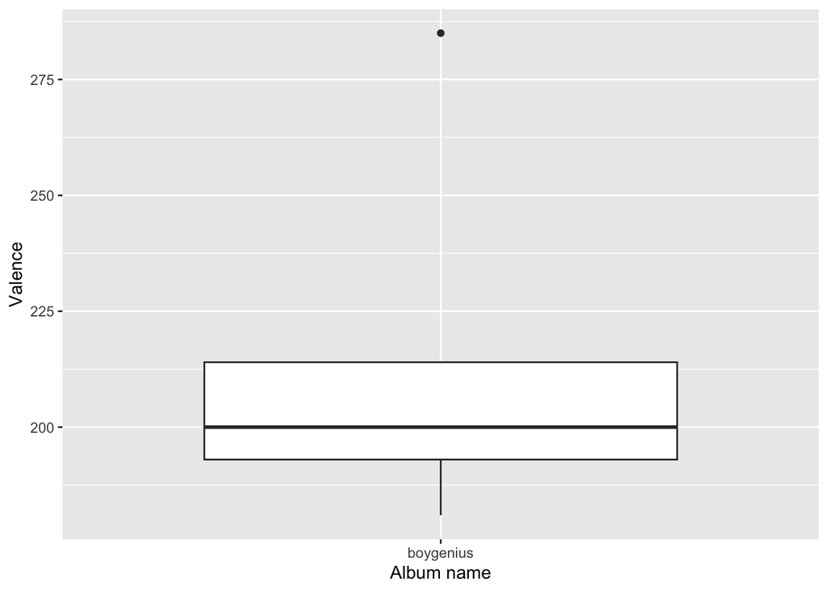

```r
# Changing album_name from a character to a factor
df$album_name <- as.factor(df$album_name)
# Plotting a boxplot
ggplot(df, aes(x=album_name, y=valence))+
  geom_boxplot()+
  labs(x="Album name", y="Valence")
```

Here, one can see a larger version of the Boygenius boxplot, where one can again see the outlier that is ‘Salt in the Wound’, which, with its valence of 285, is an outlier to the valence of the EP’s other songs. It is again the overall low valence that stood out to me, and I wondered whether there was any musical explanation for this low valence.

#### Looking for correlating variables

As I wanted to explore whether there was a musical explanation for the low valence of the music, I decided to try and find a correlation between a more technical, musical variable and the valence levels in the music. For this, I utilized the EP ‘Boygenius’, as it was the only album with multiple songs, and was hence more suitable to analysis. I constructed scatter plots for three variables, to see if there was any correlation present.

##### Tempo

I first looked at whether a song’s tempo had any impact on the song’s valence. From this scatter plot, there appears to be a negative relationship between the two variables - as tempo increases, valence tends to decrease. However, in order to see whether we can be confident in these findings, I decided to look at the p-value.

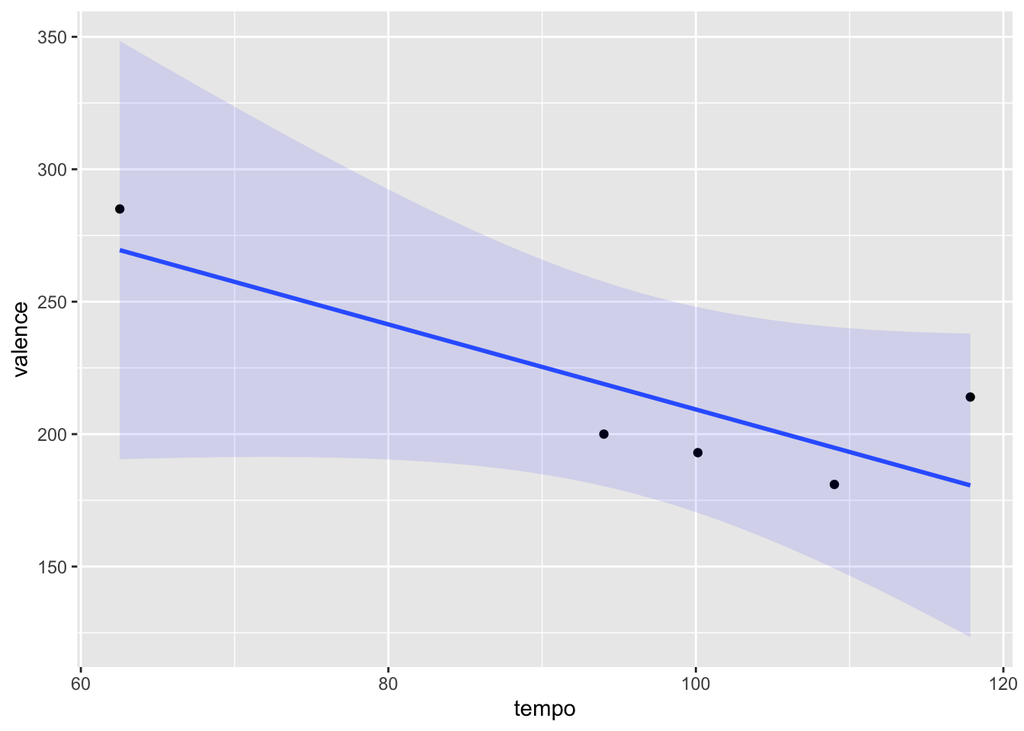

```r
#constructing a scatterplot
ggplot(df, aes(x = tempo, y = valence)) + geom_point()+ geom_smooth(method= "lm", alpha = 0.1, fill= "blue")
```

When looking at tempo’s p-value, which is 0.08565, and hence larger than 0.05, the effect of tempo on the valence of the songs is not significant at a 95% confidence level. Whilst there hence appears to be a relationship, we cannot be confident in the effect tempo has on valence due to tempo’s p-value. It is likely that the small data set impacts this, as the EP only has a total of six songs, with only five of these being part of the data set.

```r
#creating a linear regression model to find the p-value
model <- lm(valence ~ tempo, data = df)
            summary(model)
```

```
Call:
lm(formula = valence ~ tempo, data = df)

Residuals:
     1      2      3      4      5
-13.85 -16.10 -18.92  15.52  33.35

Coefficients:
            Estimate Std. Error t value Pr(>|t|)
(Intercept) 369.8823    62.6107   5.908  0.00969 **
tempo        -1.6057     0.6354  -2.527  0.08565 .
---
Signif. codes:  0 '***' 0.001 '**' 0.01 '*' 0.05 '.' 0.1 ' ' 1

Residual standard error: 26.85 on 3 degrees of freedom
Multiple R-squared:  0.6804,    Adjusted R-squared:  0.5738
F-statistic: 6.386 on 1 and 3 DF,  p-value: 0.08565
```

##### Energy

I then looked at whether the energy of a song may be correlated with the valence of a song. However, when looking at the scatter plot, from the visuals alone, it appears that there is no correlation, or at least no linear correlation, as the best fit line is nearly a straight line, with data sets appearing relatively scattered across the graph. I still decided to look at energy’s p-value.

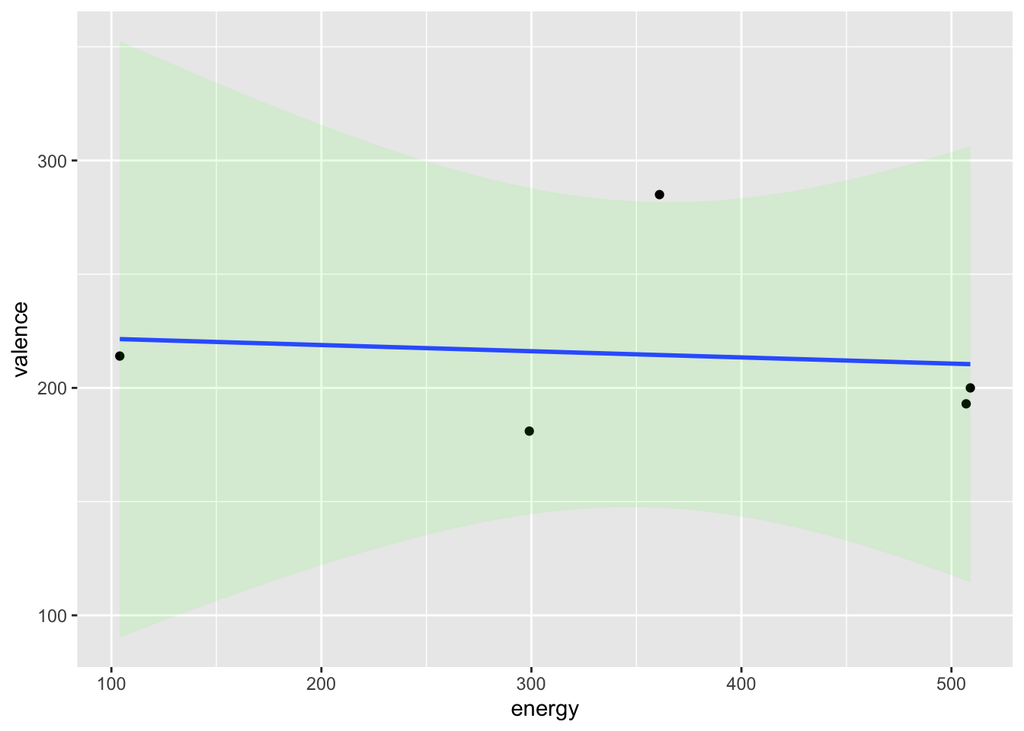

```r
#constructing a scatterplot
ggplot(df, aes(x = energy, y = valence)) + geom_point()+ geom_smooth(method= "lm", alpha = 0.1, fill= "green")
```

The p-value found, which is 0.8586, is once again larger than 0.05. Hence, again at the 95% confidence level, we cannot be confident that energy has an impact on a song’s valence - not very surprising, given the way that the graph looked like.

```r
#creating a linear regression model to find the p-value
model <- lm(valence ~ energy, data = df)
            summary(model)
```

```
Call:
lm(formula = valence ~ energy, data = df)

Residuals:
      1       2       3       4       5
-35.152 -17.488 -10.433  70.536  -7.463

Coefficients:
             Estimate Std. Error t value Pr(>|t|)
(Intercept) 224.29494   54.25451   4.134   0.0257 *
energy       -0.02723    0.14040  -0.194   0.8586
---
Signif. codes:  0 '***' 0.001 '**' 0.01 '*' 0.05 '.' 0.1 ' ' 1

Residual standard error: 47.19 on 3 degrees of freedom
Multiple R-squared:  0.01239,   Adjusted R-squared:  -0.3168
F-statistic: 0.03762 on 1 and 3 DF,  p-value: 0.8586
```

##### Loudness

The last variable I looked at in trying to see whether any musical elements explained a song’s valence is loudness. Looking at the scatter plot, it is clear that all songs have a negative loudness - in this data set, this means that the songs loudness, in decibels (dB), is below the reference level. Interestingly however, there appears to be a positive relationship between the two variables, with valence increasing when loudness increases.

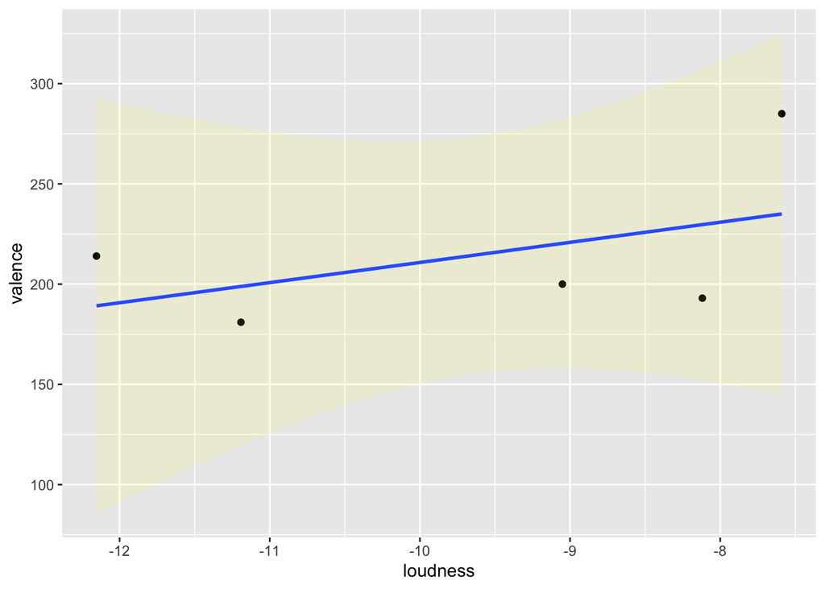

```r
#constructing a scatterplot
ggplot(df, aes(x = loudness, y = valence)) + geom_point()+ geom_smooth(method= "lm", alpha = 0.1, fill= "yellow")
```

```r
#creating a linear regression model to find the p-value
model <- lm(valence ~ loudness, data = df)
            summary(model)
```

```
Call:
lm(formula = valence ~ loudness, data = df)

Residuals:
     1      2      3      4      5
-17.83 -36.68 -20.32  50.01  24.83

Coefficients:
            Estimate Std. Error t value Pr(>|t|)
(Intercept)   311.20     103.08   3.019   0.0568 .
loudness       10.04      10.54   0.953   0.4110
---
Signif. codes:  0 '***' 0.001 '**' 0.01 '*' 0.05 '.' 0.1 ' ' 1

Residual standard error: 41.61 on 3 degrees of freedom
Multiple R-squared:  0.2323,    Adjusted R-squared:  -0.02362
F-statistic: 0.9077 on 1 and 3 DF,  p-value: 0.411
```

Overall, it appears that these ‘musical’ variables do not necessarily explain the valence levels of the songs - quite likely because loudness, energy and tempo as musical choices match the lyrics and atmosphere of a song, and are utilized by artists to create this valence level.

#### Phoebe Bridgers’ most positive song?

While overall none of the songs in the data set are very positive (although Phoebe Bridgers does have more positive music), there are still ‘the most’ positive ones in the data set. I constructed a data frame of all the music (going back to the full Phoebe Bridgers data set), to see which of the songs included is the most positive:

```r
# I first loaded the packages I needed for the analysis
library(ggplot2)
library(dplyr)

#I then imported the data into df
df <- read.csv("/Users/irisbuisman/Desktop/assignment2/dataset.csv", sep = ";", header = TRUE)

#Removal of track records that have the same name
df <- df |> distinct(track_name, .keep_all = TRUE)
#Filtering out any tracks with "feat"
df <- df |> filter(!grepl("feat.", track_name))
#creating a top three with highest valence
df |> slice_max(valence, n=3) |> dplyr::select(track_name, album_name, valence) |> knitr::kable(digits = 2)
```

| track_name | album_name | valence |
| --- | --- | --- |
| Motion Sickness | Stranger in the Alps | 623 |
| Runaway Horses - Abridged | The Greatest Rock Tunes 2022 | 304 |
| Salt In The Wound | boygenius | 285 |

The most positive song in this data set appears to be ‘Motion Sickness’, followed by the collaboration ‘Runaway Horses’ and Boygenius’ ‘Salt In The Wound’.

[Motion Sickness](https://www.youtube.com/watch?v=4EKR01aEFE0)

[video not shown]